# 3.2 Probability theory

Author

Affiliation

Vladimir Buskin

Catholic University of Eichstätt-Ingolstadt

Abstract

This section covers essential concepts from probability theory: relative frequencies and probabilities, conditional probability and Bayes’ theorem, expected values and variances, as well as the most important discrete and continuous probability distributions.

**Script**

You can find the full R script associated with this unit [here](https://osf.io/xgbsk).

## Recommended reading

Most accessible:

> Baguley (2012): Chapter 2

Technical:

> Heumann, Schomaker, and Shalabh (2022): Chapter 7

> Agresti and Kateri (2022): Chapter 2

Proof-based:

> Casella and Berger (2002): Chapters 1 & 2

## Preparation

We will draw on the genitive data published by Grafmiller (2014), who investigates the influence of a series of phonetic, semantic, contextual, and psycholinguistic factors on the choice between the synthetic *s*-genitive and the periphrastic *of*-genitive. Some representative examples are given below (Grafmiller 2014: 471):

1. *and ran **the Grizzlies’ winning streak** to four straight.* (Brown Corpus, A13)
2. *He was **the sidekick of Gene Autry** I believe* (Switchboard Corpus, 2131)

```r
library(tidyverse)
library(readxl)

genitive <- read_xlsx("Grafmiller_genitive_alternation.xlsx")
```

```r
# Overview
glimpse(genitive)
```

## What is probability?

The OED provides several non-technical definitions of the term *probability*, which include

- ‘the extent to which something is likely to happen or be the case’[^1] and
- a ‘thing judged likely to be true, to exist, or to happen’[^2].

<sup>1</sup> See https://doi.org/10.1093/OED/1639707847.

<sup>2</sup> See https://doi.org/10.1093/OED/3638534852.

While these dictionary definitions capture the main intuition behind probability in everyday language, they leave important questions unanswered. How can we quantify probability? How can we describe the full range of possible outcomes — and their respective probabilities — in a systematic way? To address these concerns, we need to refine our current view of probability.

### Relative frequency

Agresti & Kateri (2022: 29) adduce a frequency-based interpretation of probability:

> “For an observation of a random phenomenon, the **probability** of a particular outcome is the proportion of times that outcome would occur in an indefinitely long sequence of like observations, under the same conditions.”

The set of all possible outcomes of a random phenomenon is called the **sample space** $S$. For instance, the sample space of genitive choices is $S = \{\text{s}, \text{of}\}$. The probability of an event[^3] $A$, denoted $P(A)$, corresponds to the long-term relative frequency of $A$ as the number of observations $n$ increases. The relative frequency $f(A)$ is obtained by dividing the frequency of occurrence $n(A)$ by the sample size $n$, i.e.,

<sup>3</sup> An event is understood as any subset of the sample space $S$, comprising one or more outcomes.

$$f(A) = \frac{n(A)}{n}.
\tag{1}$$

Heumann et al. (2022: 118) explain that $f(A)$ converges to the probability $P(A)$ as $n$ approaches infinity:

$$P(A) = \lim_{n\to\infty} \frac{n(A)}{n}.
\tag{2}$$

Strictly speaking, this is not a limit in the usual mathematical sense, since relative frequencies are themselves random: The **law of large numbers** guarantees that large deviations of $f(A)$ from $P(A)$ become increasingly unlikely as $n$ grows.

**Example 1 (Relative frequency)** In the `genitive` data, we can use relative frequencies to estimate the probability that possession is indicated using the *of* or *s* genitive, respectively.

```r
# Probability of genitive type
genitive %>%
  count(Type) %>%
  mutate(rel_freq = n/sum(n))
```

```
# A tibble: 2 × 3
  Type      n rel_freq
  <chr> <int>    <dbl>
1 of     3103    0.609
2 s      1995    0.391
```

**Kolmogorov’s axioms**

On the most abstract level, probabilities are defined as functions that assign values in the interval $[0, 1]$ to the events of a sample space $S = \{s_1, s_2, ..., s_n\}$, subject to certain conditions.

The Russian mathematician Andrei Kolmogorov (1903–1987) proposed three axioms that a probability function $P$ must satisfy:

1. Every event $A$ in the sample space $S$ has a non-negative probability:

$$P(A) \geq 0.
\tag{3}$$

2. The probability of the sample space $S$ (i.e., the probability that *some* outcome occurs) is 1:

$$P(S) = 1.
\tag{4}$$

3. Assuming two disjoint (i.e., mutually exclusive) events $A$ and $B$, then

$$P(A \cup B) = P(A) + P(B).
\tag{5}$$

Note that this axiom can be generalised to infinite series of pairwise disjoint events $A_i$:

$$P\left(\bigcup\limits_{i=1}^{\infty} A_i\right) = \sum\limits_{i=1}^{\infty} P(A_i).$$

### Conditional probability

In many linguistic contexts, we’re interested in the probability of one event occurring given that another event has already occurred. This concept is captured by **conditional probability**, which measures the probability of event $A$ happening when we know that event $B$ has taken place. It is a way of taking additional information into account.

The conditional probability of $A$ given $B$ is denoted $P(A|B)$ and is defined as:

$$P(A \mid B) = \frac{P(A \cap B)}{P(B)},
\tag{6}$$

provided that $P(B) > 0$. This formula tells us that the conditional probability is the ratio of the probability that both events occur to the probability that the conditioning event occurs.

One of the most important results in probability theory is **Bayes’ theorem**, which allows us to “reverse” conditional probabilities:

$$P(A \mid B) = \frac{P(B \mid A) \cdot P(A)}{P(B)}.
\tag{7}$$

This theorem is fundamental to **Bayesian statistics**.

**Example 2 (Conditional probability)** Using the `genitive` data, we will compute the probabilities:

- $P(\text{Genitive = s})$: The probability an NP takes the ‘s’ genitive.

```r
# P(s)
genitive %>%
  count(Type) %>%
  mutate(prob = n / sum(n)) %>%
  filter(Type == "s")
```

```
# A tibble: 1 × 3
  Type      n  prob
  <chr> <int> <dbl>
1 s      1995 0.391
```

- $P(\text{Genitive = s} \mid \text{Possessor Animacy = inanimate})$: The probability that an NP takes the ‘s’ genitive, given that the possessor is inanimate.

```r
# P(s | inanimate)
genitive %>%
  filter(Possessor_Animacy2 == "inanimate") %>%
  count(Type) %>%
  mutate(prob = n / sum(n)) %>%
  filter(Type == "s")
```

```
# A tibble: 1 × 3
  Type      n  prob
  <chr> <int> <dbl>
1 s       544 0.178
```

- $P(\text{Genitive = s} \mid \text{Possessor Animacy = inanimate}, \text{Genre = Press})$: The probability that an NP takes the ‘s’ genitive, given that the possessor is inanimate **and** that it occurs in the text category ‘Press’.

```r
# P(s | inanimate, press)
genitive %>%
  filter(Possessor_Animacy2 == "inanimate", Genre == "Press") %>%
  count(Type) %>%
  mutate(prob = n / sum(n)) %>%
  filter(Type == "s")
```

```
# A tibble: 1 × 3
  Type      n  prob
  <chr> <int> <dbl>
1 s       288 0.448
```

- What is the probability that a possessor is inanimate, given that the genitive is ‘s’, i.e. $P(\text{inanimate} \mid \text{s})$? We compute

$$P(\text{inanimate} \mid \text{s}) = \frac{P(\text{s} \mid \text{inanimate}) \cdot P(\text{inanimate})}{P(\text{s})}.$$

```r
# Total number of observations
N_total <- nrow(genitive)

# Count of animacy = inanimate
n_inanimate <- genitive %>%
  filter(Possessor_Animacy2 == "inanimate") %>%
  count() %>%
  pull(n)

# Count of type = s
n_sgen <- genitive %>%
  filter(Type == "s") %>%
  count() %>%
  pull(n)

# Count of type = s AND animacy = inanimate
n_sgen_inanim <- genitive %>%
  filter(Possessor_Animacy2 == "inanimate", Type == "s") %>%
  count() %>%
  pull(n)

# Now compute:
# P(s | inanimate) = n_sgen_inanim / n_inanimate
# P(inanimate) = n_inanimate / N_total
# P(s) = n_sgen / N_total

p_inanim_sgen <- (n_sgen_inanim / n_inanimate) * (n_inanimate / N_total) / (n_sgen / N_total)

p_inanim_sgen
```

```
[1] 0.2726817
```

```r
# Sanity check: the proportion of inanimate possessors among all s-genitives
n_sgen_inanim / n_sgen
```

```
[1] 0.2726817
```

Both computations yield the same result, as the terms $n_{\text{inanimate}}$ and $N_{\text{total}}$ cancel out.

## Probability distributions

Recall the concept of **random variables** introduced in 3.1 Data, variables, samples. They describe random processes, which means that the outcomes of the experiment are not pre-determined in any way; there is always some degree of uncertainty involved. Each outcome occurs with a certain probability.

When we associate each outcome of a random variable with a probability, we obtain its **probability distribution**. A function that explicitly maps probabilities onto the discrete outcomes of a discrete random variable $X$ is called **probability mass function** ($pmf$). In the continuous case, we speak of a **probability density function** ($pdf$).

**Example 3 (Pmf)** We can establish the probability distribution of genitive types as follows:

```r
# Count tokens and compute relative frequencies
gen_type <- genitive %>%
  count(Type) %>%
  mutate(rel_freq = n/sum(n))

# Ensure that probabilities sum up to 1
sum(gen_type$rel_freq)
```

```
[1] 1
```

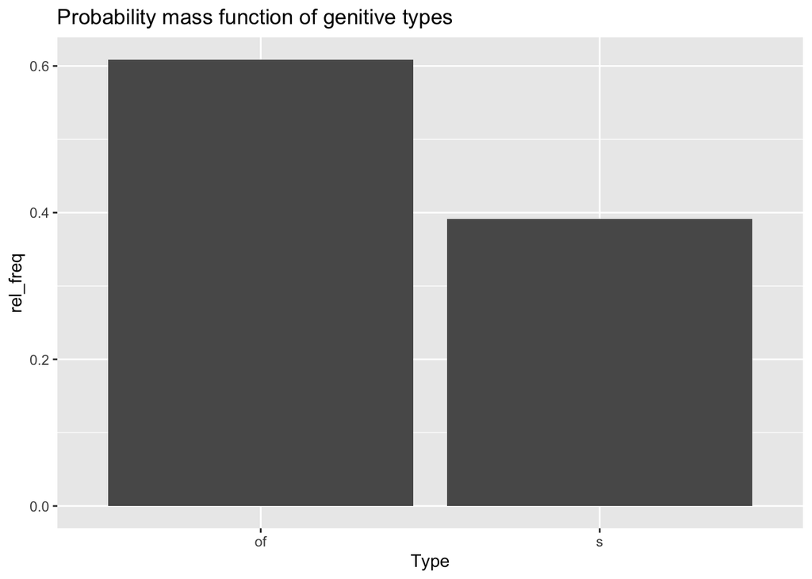

```r
# Plot the PMF
gen_type %>%
  ggplot(aes(x = Type, y = rel_freq)) +
  geom_col() +
  labs(title = "Probability mass function of genitive types")
```

### Expected value and variance

A probability distribution can be summarised by a few key characteristics. The most important one is the **expected value** $E(X)$, also known as the **expectation** or **population mean** and often denoted $\mu$. Intuitively, it is the average value we would obtain if we could observe a random variable indefinitely often, much like probabilities correspond to long-term relative frequencies.

For a discrete random variable $X$, the expected value is the sum of all possible outcomes $x$, each weighted by its probability:

$$E(X) = \sum_{x} x \cdot P(X = x).
\tag{8}$$

**Example 4 (Expected value of a die)** A fair die has the outcomes $1, \dots, 6$, each with probability $\frac{1}{6}$. Its expected value is

$$E(X) = 1 \cdot \tfrac{1}{6} + 2 \cdot \tfrac{1}{6} + 3 \cdot \tfrac{1}{6} + 4 \cdot \tfrac{1}{6} + 5 \cdot \tfrac{1}{6} + 6 \cdot \tfrac{1}{6} = \frac{21}{6} = 3.5.$$

Note that 3.5 can never be rolled: The expected value is not necessarily a possible outcome, let alone the most likely one, but the long-term average. If we simulate a large number of rolls, their mean comes very close to 3.5:

```r
# Outcomes and their probabilities
x <- 1:6
p <- rep(1/6, 6)

# Expected value
sum(x * p)
```

```
[1] 3.5
```

```r
# Mean of 10,000 simulated rolls
set.seed(123)
mean(sample(1:6, size = 10000, replace = TRUE))
```

```
[1] 3.4697
```

Expected values can also be computed for categorical variables, as long as we code their outcomes numerically. Let $X = 1$ if a genitive is an *s*-genitive and $X = 0$ if it is an *of*-genitive, with $P(X = 1) = \pi$. Then

$$E(X) = 1 \cdot \pi + 0 \cdot (1 - \pi) = \pi.
\tag{9}$$

In other words, the expected value of such a 0/1 variable (also called an **indicator variable**) is simply the probability of the outcome coded as 1. Accordingly, the mean of a 0/1 coded variable equals the relative frequency of 1s. This insight will become important for logistic regression, which models the expected value $E(Y) = P(Y = 1)$ of a binary response variable.

```r
genitive %>%
  mutate(s_gen = if_else(Type == "s", 1, 0)) %>% # code s = 1, of = 0
  summarise(mean_s_gen = mean(s_gen)) # same as the relative frequency of s
```

```
# A tibble: 1 × 1
  mean_s_gen
       <dbl>
1      0.391
```

The **variance** measures how much the outcomes vary around the expected value. It is defined as the expected squared deviation from $E(X)$:

$$Var(X) = E\left[(X - E(X))^2\right] = \sum_{x} (x - E(X))^2 \cdot P(X = x).
\tag{10}$$

Its square root $\sigma = \sqrt{Var(X)}$ is the **standard deviation**, which is expressed in the same unit as $X$ itself. For the die, we obtain $Var(X) = \frac{17.5}{6} \approx 2.92$ and $\sigma \approx 1.71$:

```r
# Variance
var_die <- sum((x - 3.5)^2 * p)

var_die
```

```
[1] 2.916667
```

```r
# Standard deviation
sqrt(var_die)
```

```
[1] 1.707825
```

For a 0/1 variable with $P(X = 1) = \pi$, the variance simplifies to $Var(X) = \pi(1 - \pi)$, which is largest for $\pi = 0.5$.

For continuous random variables, the sum is replaced by an integral over the density $f(x)$, i.e., $E(X) = \int x f(x) \, dx$. The interpretation remains the same.

**Population vs. sample**

$E(X)$ and $Var(X)$ are properties of a probability distribution, i.e., of the population. The sample mean $\bar{x}$ and the sample variance $s^2$ (see 3.3 Descriptive statistics) are their counterparts in the data: They **estimate** $E(X)$ and $Var(X)$, just as relative frequencies estimate probabilities. By the law of large numbers, the sample mean gets closer to $E(X)$ as the sample size increases.

### Discrete distributions

#### Uniform distribution

If all discrete outcomes have the same probability, their distribution is called **uniform**. A well-known example is the toss of a coin: If the coin is fair, the outcomes $\{\text{Heads}\}$ and $\{\text{Tails}\}$ are equally likely. More generally, if a discrete random variable $X$ is uniformly distributed over $k$ different outcomes, then any outcome $x_i$ has the probability

$$P(X = x_i) = \frac{1}{k}.
\tag{11}$$

If we toss a fair coin once, the sample space is $S = \{\text{Heads}, \text{Tails}\}$, and we have $P(\text{Heads}) = P(\text{Tails}) = \frac{1}{2}$.

Note that all probabilities have to add up to 1, i.e.,

$$\sum_{x} P(X = x) = 1.
\tag{12}$$

**Example 5 (Uniform distribution)** A single throw of a die has the sample space $S = \{1, 2, 3, 4, 5, 6\}$. The long-term relative frequency of each outcome, and thus its probability, should be $1/6 \approx 0.17$.

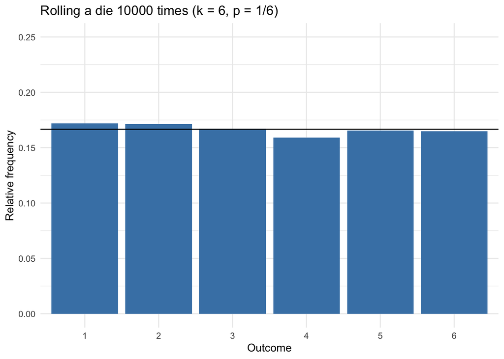

```r
# Load libraries
library(tidyverse)

# First, set a seed for reproducibility; this ensures that we always generate the 'same' random numbers
set.seed(123)

# Simulate 10,000 rolls of a fair six-sided die
die_rolls <- sample(1:6, size = 10000, replace = TRUE)

# Plot the probability mass function
ggplot(data.frame(die_rolls), aes(x = factor(die_rolls))) +
  geom_bar(aes(y = after_stat(count / sum(count))), fill = "steelblue") +
  geom_hline(yintercept = 1/6, col = "black") +
  labs(title = "Rolling a die 10000 times (k = 6, p = 1/6)",
       y = "Relative frequency",
       x = "Outcome") +
  scale_y_continuous(limits = c(0, 0.25)) +
  theme_minimal()
```

#### Binomial distribution

Many corpus-linguistic studies are concerned with discrete random variables that have exactly two outcomes, such as the dative alternation (*give somebody something* vs. *give something to somebody*), the particle placement alternation (*pick something up* vs. *pick up something*), or object realisation (*I’ve eaten something* vs. *I’ve eaten Ø*).

A single observation of such a variable is called a **Bernoulli trial**: One of the two outcomes (‘success’) occurs with a fixed probability $\pi$, the other one (‘failure’) with the probability $1 - \pi$. If we make $n$ independent Bernoulli trials, the **number of successes** $X$ follows a **binomial distribution**.[^4] We can also use the shorthand notation

<sup>4</sup> The natural extension of the binomial distribution to $k$ different outcomes is called the **multinomial distribution** with index $n$ and probabilities $\pi_1, \pi_2, \dots, \pi_k$.

$$X \sim Binom(n, \pi).$$

The elements inside the parentheses are the **parameters** of the distribution: the number $n$ of independent trials and the probability $\pi$ of ‘success’. As such, they determine the shape of the probability mass function. Since each trial contributes $\pi$ to the expected number of successes (cf. Equation 9), the expected value and variance of a binomial distribution are

$$E(X) = n\pi, \qquad Var(X) = n\pi(1 - \pi).
\tag{13}$$

**Example 6 (Binomial distribution)** Suppose we throw a fair coin $30$ times and count how often we obtain ‘heads’. The expected number of heads is $E(X) = 30 \cdot 0.5 = 15$, with a standard deviation of $\sqrt{30 \cdot 0.5 \cdot 0.5} \approx 2.74$. As the plot shows, 15 is the most likely outcome, but values a few heads above or below are almost as likely.

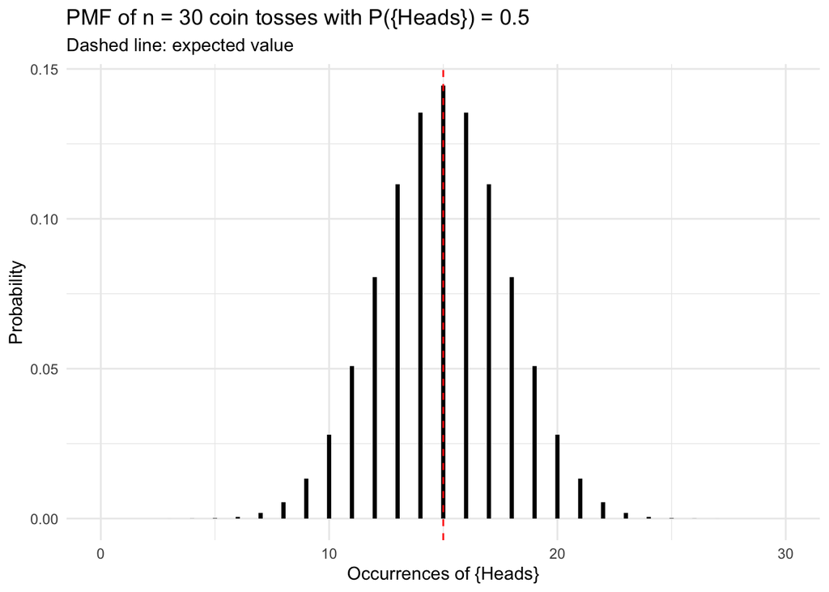

```r
# Set parameters for binomial distribution
n <- 30    # Number of trials
pi <- 0.5  # Probability of HEADS

# Set up the pmf
successes <- 0:n
prob_mass <- dbinom(successes, size = n, prob = pi)

# Create a data frame for plotting
binom_data <- data.frame(successes = successes, probability = prob_mass)

# Basic plot approach
ggplot(binom_data, aes(x = successes, y = probability)) +
  geom_segment(aes(xend = successes, yend = 0), linewidth = 1.2) +
  geom_vline(xintercept = n * pi, linetype = "dashed", col = "red") + # expected value
  labs(title = "PMF of n = 30 coin tosses with P({Heads}) = 0.5",
       subtitle = "Dashed line: expected value",
       x = "Occurrences of {Heads}", y = "Probability") +
  theme_minimal()
```

The binomial distribution also underlies the **expected frequencies** of the $\chi^2$ test (see 3.5 Chi-squared test): If a cell of a contingency table has the probability $\pi$ under $H_0$, its expected frequency in a sample of $n$ observations is $n\pi$.

#### Poisson distribution

The Poisson distribution is particularly suitable for frequency data, which is ubiquitous in corpus linguistics. A Poisson-distributed random variable is fully determined by its rate parameter $\lambda$, which indicates how often events occur on average within a given interval (e.g., per 1,000 words):

$$X \sim Pois(\lambda).$$

A special property of the Poisson distribution is that $\lambda$ is both its expected value and its variance:

$$E(X) = Var(X) = \lambda.
\tag{14}$$

Assume a word occurs 3 times per 1,000 words on average. We would define the rate parameter as $\lambda = 3$, which is the expected number of occurrences in a stretch of 1,000 words. The plot shows that 2 and 3 occurrences are equally likely: For whole-number values of $\lambda$, both $\lambda - 1$ and $\lambda$ are the most likely outcomes.

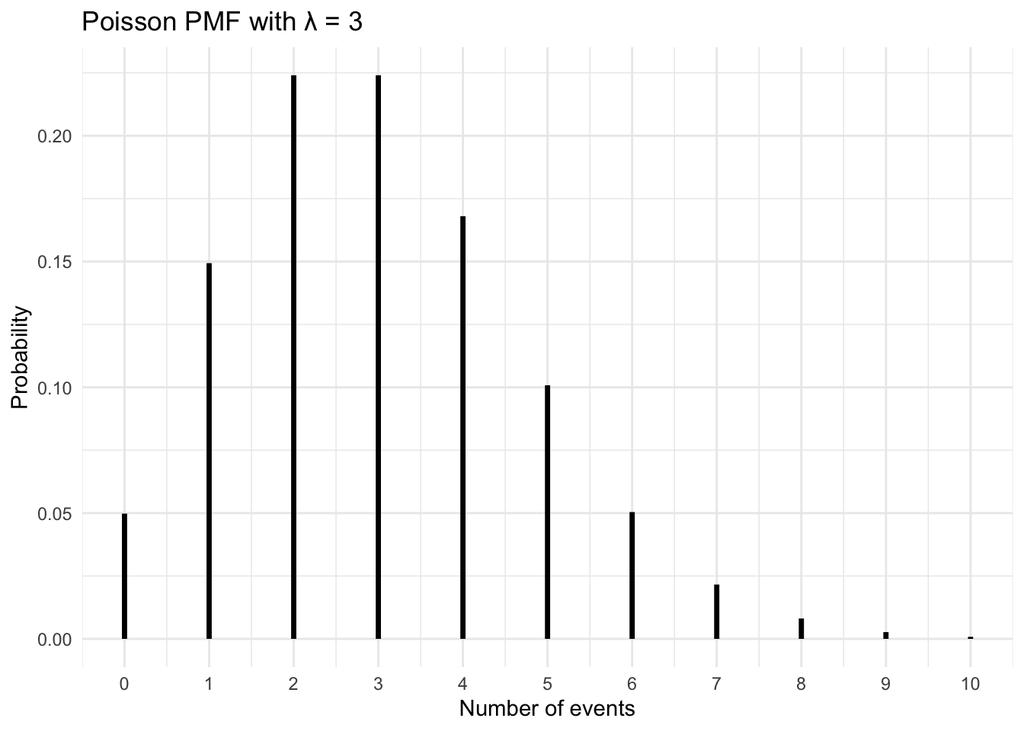

```r
# Define the occurrence rate
lambda <- 3

# Define the range of x values
x_range <- 0:10

# Compute PMF values using dpois()
poisson_pmf <- data.frame(
  x = x_range,
  probability = dpois(x_range, lambda)
)

# Create the PMF plot using ggplot
ggplot(poisson_pmf, aes(x = x, y = probability)) +
  geom_segment(aes(xend = x, yend = 0), linewidth = 1.2) +
  labs(title = "Poisson PMF with λ = 3",
       x = "Number of events",
       y = "Probability") +
  scale_x_continuous(breaks = x_range) +
  theme_minimal()
```

### Continuous distributions

#### Normal distribution

A great number of numerical variables in the world approximately follow the well-known **normal** (or Gaussian) **distribution**, which includes test scores, weight and height, among many others. The plot below illustrates its characteristic bell-shape: Most observations are in the middle, with considerably fewer near the fringes. For example, most people are rather “average” in height; there are only few people that are extremely short or extremely tall.

The normal distribution is typically described in terms of two parameters: The population mean $\mu$ and the population variance $\sigma^2$. If a random variable $X$ is normally distributed, we typically use the notation in Equation 15.

$$X \sim \mathcal{N}(\mu, \sigma^2).
\tag{15}$$

The $\mu$ parameter corresponds to the **expected value** $E(X)$ (see Equation 8), which lies at the centre of the bell curve.

The spread of the values around the expectation is the population **variance** $Var(X) = E\left[(X - E(X))^2\right]$ (see Equation 10), which corresponds to $\sigma^2$.

The population **standard deviation** $\sigma = \sqrt{Var(X)}$ indicates the typical distance of the values from the expectation.

**Example 7 (Normal distribution)** The plot illustrates a standard normal distribution for $X \sim \mathcal{N}(0, 1)$. The $y$-axis indicates the probability density. Note that since $X$ is a continuous variable, the probability of any single value is 0, i.e., $P(X = x) = 0$. We can only obtain probabilities for **intervals** of values, which are given by the area under the curve:

$$P(a \leq X \leq b) = \int_a^b f(x)dx.
\tag{16}$$

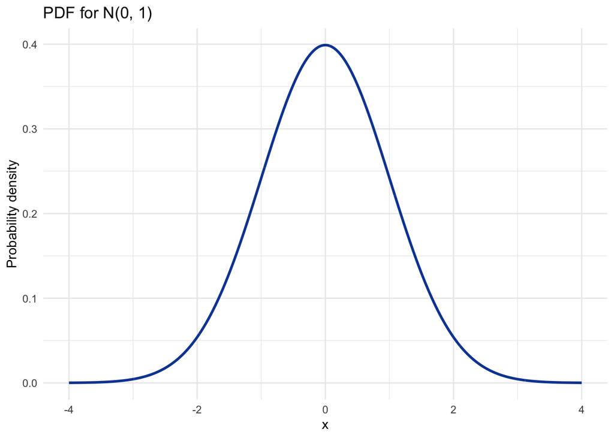

```r
# Set parameters for normal distribution
mu <- 0     # mean (expectation)
sigma <- 1  # standard deviation (square root of variance)
variance <- sigma^2

# Generate a sequence of x-values in a range of +/- 4 standard deviations from the mean
x_values <- seq(mu - 4*sigma, mu + 4*sigma, length.out = 1000)

# Collect everything in a data frame
norm_data <- data.frame(
  x = x_values,
  density = dnorm(x_values, mean = mu, sd = sigma)
)

# Plot the density
ggplot(norm_data, aes(x = x, y = density)) +
  geom_line(linewidth = 1, color = "#0D47A1") +
  labs(
    title = "PDF for N(0, 1)",
    x = "x",
    y = "Probability density") +
  theme_minimal()
```

**Quick facts about the Gaussian bell curve**

Quite interestingly,

- 68% of all values fall within one standard deviation of the mean,
- 95% within two, and
- 99.7% within three.

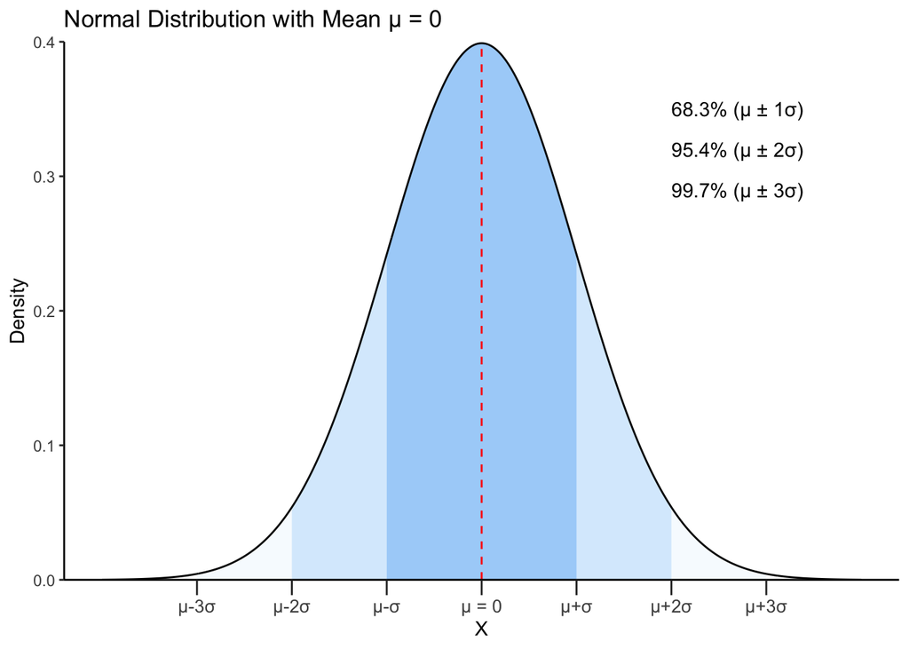

#### Lognormal distribution

While many variables follow a normal distribution, others exhibit a characteristic right-skewed pattern where most observations cluster near zero but some extend far into the positive tail. This is particularly common with reaction times or survival data.

The **log-normal distribution** describes variables whose natural logarithm follows a normal distribution. If $\ln(X) \sim \mathcal{N}(\mu, \sigma^2)$, then $X$ follows a log-normal distribution, denoted as:

$$X \sim LogN(\mu, \sigma^2).$$

The parameters $\mu$ and $\sigma^2$ refer to the mean and variance of the underlying normal distribution (i.e., of $\ln(X)$), not of $X$ itself. In fact, $e^{\mu}$ is the **median** of $X$, whereas its expected value is larger due to the long right tail:

$$E(X) = e^{\mu + \sigma^2/2}.
\tag{17}$$

**Example 8 (Lognormal distribution)** Word frequency distributions are heavily right-skewed: Most words occur rarely, while a few occur very frequently (cf. Zipf’s law). The log-normal distribution is one of several models that have been proposed for such distributions (cf. Baayen 2001).

For $\mu = 2$ and $\sigma = 1$, the median is $e^2 \approx 7.39$, while the expected value is $e^{2.5} \approx 12.18$.

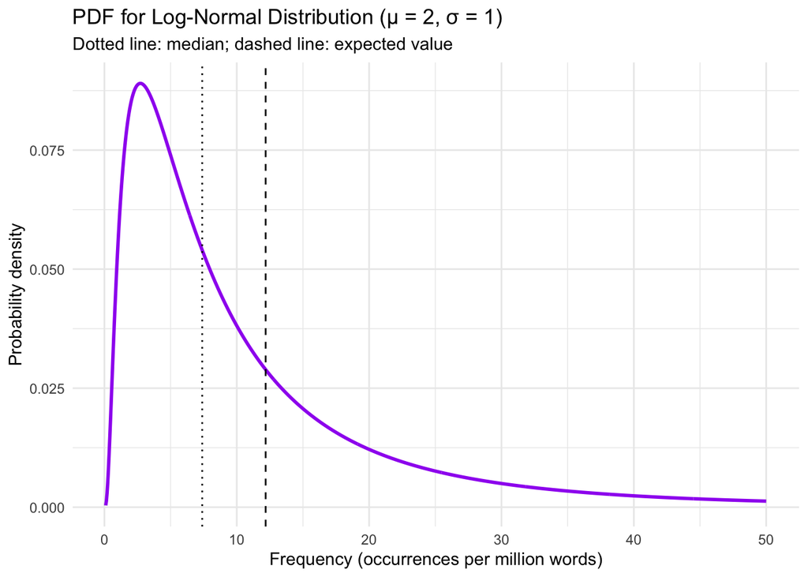

```r
# Set parameters for log-normal distribution
mu_log <- 2      # Mean of the underlying normal distribution (log scale)
sigma_log <- 1   # Standard deviation of the underlying normal distribution

# Generate x values on the positive real line
x_values <- seq(0.1, 50, length.out = 1000)

# Calculate the probability density
lognorm_data <- data.frame(
  x = x_values,
  density = dlnorm(x_values, meanlog = mu_log, sdlog = sigma_log)
)

# Plot the log-normal distribution
ggplot(lognorm_data, aes(x = x, y = density)) +
  geom_line(linewidth = 1, color = "purple") +
  geom_vline(xintercept = exp(mu_log), linetype = "dotted") + # median
  geom_vline(xintercept = exp(mu_log + sigma_log^2/2), linetype = "dashed") + # expected value
  labs(
    title = "PDF for Log-Normal Distribution (μ = 2, σ = 1)",
    subtitle = "Dotted line: median; dashed line: expected value",
    x = "Frequency (occurrences per million words)",
    y = "Probability density"
  ) +
  theme_minimal()
```

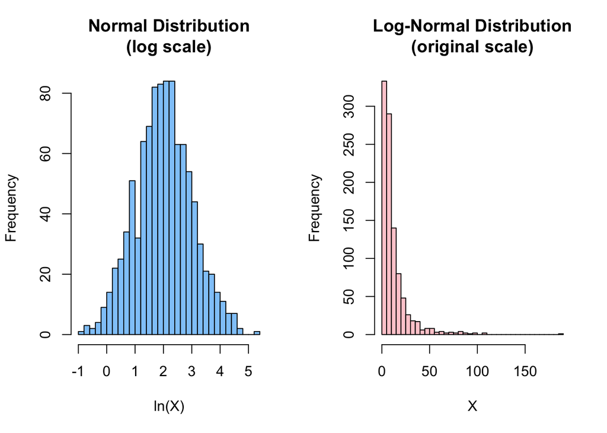

```r
# Show the relationship between normal and log-normal
# Generate sample data
set.seed(123)
normal_sample <- rnorm(1000, mean = mu_log, sd = sigma_log)
lognormal_sample <- exp(normal_sample)

# Create comparison plot
par(mfrow = c(1, 2))
hist(normal_sample, main = "Normal Distribution\n(log scale)",
     xlab = "ln(X)", col = "#90CAF9", breaks = 30)
hist(lognormal_sample, main = "Log-Normal Distribution\n(original scale)",
     xlab = "X", col = "#FFCDD2", breaks = 30)
```

#### Gamma distribution

The **Gamma distribution** is a flexible family for continuous, strictly positive random variables. It is parameterised by a shape $k > 0$ and a rate $\lambda > 0$ (equivalently, a scale $\theta = 1/\lambda$):

$$X \sim \text{Gamma}(k, \lambda), \qquad E(X) = \frac{k}{\lambda}, \qquad Var(X) = \frac{k}{\lambda^2}.$$

The **chi-squared distribution**, which is central to many hypothesis tests (see 3.5 Chi-squared test), is a special case of the Gamma distribution: A $\chi^2$ distribution with $\nu$ degrees of freedom corresponds to $\text{Gamma}(k = \nu/2, \lambda = 1/2)$.

**Example 9 (Gamma distribution)** In linguistics, the Gamma family is well suited to ratio-scaled acceptability data collected via Magnitude Estimation, where participants assign positive real-valued scores to stimuli. Because such scores have a natural zero and are right-skewed, the normal distribution is a poor fit; the Gamma accommodates this naturally (see Horsch & Buskin 2026 for a recent study). For $k = 1.25$ and $\lambda = 1.5$, the expected rating is $E(X) = 1.25/1.5 \approx 0.83$.

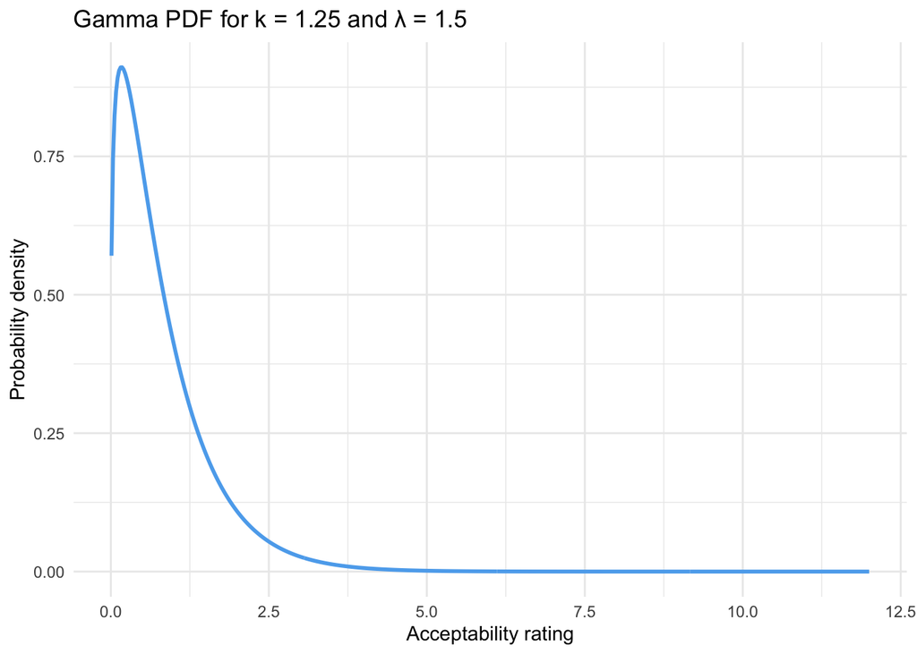

```r
gamma_data <- tibble(x = seq(0.01, 12, length.out = 500)) %>%
  mutate(density = dgamma(x, shape = 1.25, rate = 1.5))

ggplot(gamma_data, aes(x = x, y = density)) +
  geom_line(linewidth = 1, color = "steelblue2") +
  labs(
    title  = "Gamma PDF for k = 1.25 and λ = 1.5",
    x      = "Acceptability rating",
    y      = "Probability density"
  ) +
  theme_minimal()
```

### Overview

Expected values and variances of common distributions

| Distribution | Type | Parameters | $E(X)$ | $Var(X)$ |
| --- | --- | --- | --- | --- |
| Bernoulli | discrete | $\pi$ | $\pi$ | $\pi(1-\pi)$ |
| Binomial | discrete | $n, \pi$ | $n\pi$ | $n\pi(1-\pi)$ |
| Poisson | discrete | $\lambda$ | $\lambda$ | $\lambda$ |
| Normal | continuous | $\mu, \sigma^2$ | $\mu$ | $\sigma^2$ |
| Log-normal | continuous | $\mu, \sigma^2$ | $e^{\mu + \sigma^2/2}$ | $(e^{\sigma^2} - 1)e^{2\mu + \sigma^2}$ |
| Gamma | continuous | $k, \lambda$ | $k/\lambda$ | $k/\lambda^2$ |

## Exercises

**Solutions**

You can find the solutions to the exercises [here](https://osf.io/dx7ez/files/2mfej).

## Tier 1

**Exercise 1** Make suggestions for probability distributions that could be helpful for modelling the following linguistic variables and explain your choice:

1. Analytic vs. synthetic comparatives (*more scary* vs. *scarier*)
2. Number of pronunciation errors per minute
3. Frequencies of modal verbs in American English
4. Article choice (indefinite vs. definite vs. zero-article)
5. The time it takes to read a word aloud (in ms)
6. Grammatical acceptability ratings on a Likert-scale ranging from 1 to 5

**Exercise 2** Let genitive `Type` be a Bernoulli-distributed variable, which is defined as

$$\text{Type} = \begin{cases}
\text{s} & \text{with probability } \pi \\
\text{of} & \text{with probability } 1-\pi
\end{cases}$$

for $0 < \pi < 1$. If we observe $n$ independent genitives, the number of *s*-genitives $X$ follows a binomial distribution with the probability mass function

$$f(x; n, \pi) = \binom{n}{x}\pi^x(1-\pi)^{n-x},$$

where $n$ is the number of independent trials, $\pi$ the probability of ‘success’, and $x$ the observed number of successes.

Baguley (2012: 67) provides the code example below for plotting a discrete $pmf$.

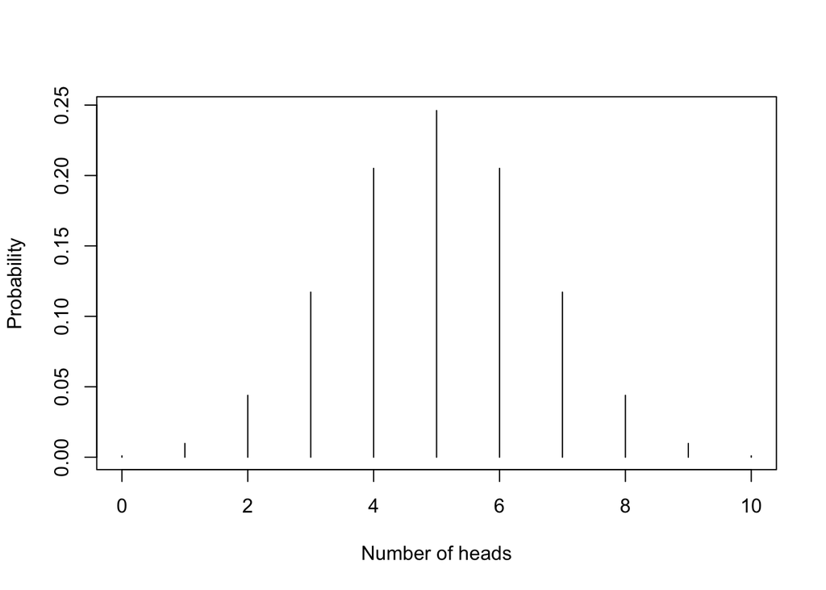

```r
# Vector containing the numbers of successes
heads <- 0:10 # observing 'heads' 0, ..., 10 times

# Get probability mass for each success (fair coin -> P(Heads) = 0.5)
prob.mass <- dbinom(heads, 10, 0.5) # throwing the coin 10 times

# Plot the PMF
plot(heads, prob.mass, pch = NA, xlab = "Number of heads", ylab = "Probability")

# Create a spikey plot
segments(x0 = heads, y0 = 0, x1 = heads, y1 = prob.mass)
```

Adjust the code to plot the $pmf$ for the number of *s*-genitives in $n = 50$ observations, where $\pi = 0.85$. Provide a brief visual description of the distribution. What does the shape tell you about the likelihood of observing fewer than 40 successes?

**Exercise 3** For the distribution in Exercise 2:

1. Compute the expected number of *s*-genitives and the standard deviation using Equation 13. Add the expected value to your plot as a vertical line, e.g., with `abline(v = ...)`.
2. Why is the probability of observing exactly the expected value 0 in this case?
3. Simulate 10,000 samples of 50 genitives each with `rbinom(n = 10000, size = 50, prob = 0.85)` and compute their mean and standard deviation. Compare them to your results from (a).

**Exercise 4** Let $R$ be a continuous random variable measuring reaction times in lexical decision tasks. We approximate the measurements with a normal distribution parametrised by

$$R \sim \mathcal{N}(\mu = 500, \sigma = 150),$$

which can be visualised as follows:

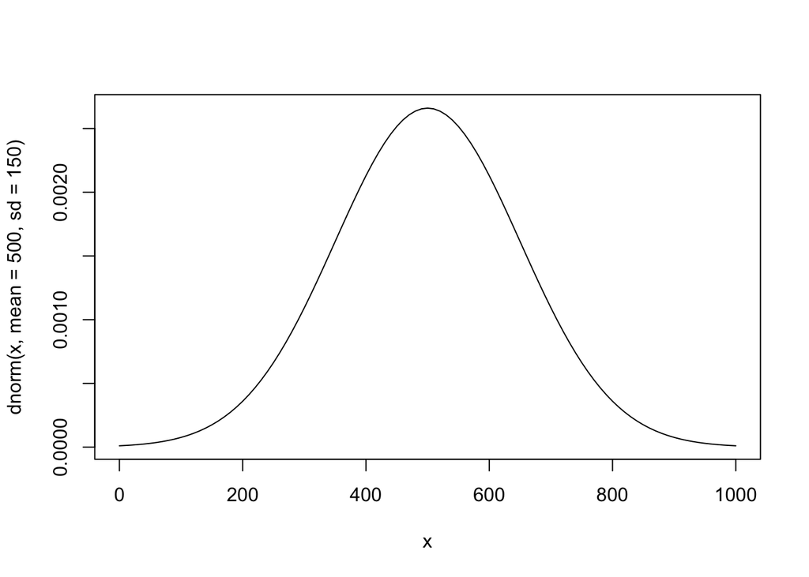

```r
curve(dnorm(x, mean = 500, sd = 150), xlim = c(0, 1000))
```

Describe how the shape of the bell curve changes for $\sigma = 50$, $\sigma = 200$ and $\sigma = 350$. What do these changes mean for the distribution of reaction times?

## Tier 2

**Exercise 5** If a variable follows a binomial distribution and we know the number of trials $n$ and the probability of success $\pi$, we can compute:

- the probability of observing a specific number of successes with `dbinom()`:

```r
# Example: P(4 heads from 10 tosses of a fair coin)
dbinom(x = 4, size = 10, prob = 0.5)
```

```
[1] 0.2050781
```

- the cumulative probability of up to $x$ successes with `pbinom()`:

```r
# Example: P(up to 4 heads from 10 tosses of a fair coin)
pbinom(q = 4, size = 10, prob = 0.5)
```

```
[1] 0.3769531
```

```r
# P(5 or more heads from 10 tosses of a fair coin)
1 - pbinom(q = 4, size = 10, prob = 0.5)
```

```
[1] 0.6230469
```

- random simulated numbers of successes with `rbinom()`:

```r
# Repeats the experiment of tossing a coin 10 times four times and
# shows the number of heads in each repetition
rbinom(n = 4, size = 10, prob = 0.5)
```

```
[1] 3 3 3 5
```

Interpret the output of the two code chunks below with reference to the genitive `Type` variable from Exercise 2.

```r
1 - pbinom(q = 80, size = 100, prob = 0.85)
```

```
[1] 0.8934557
```

```r
rbinom(n = 50, size = 15, prob = 0.15)
```

```
 [1] 2 3 2 0 0 1 4 1 2 3 6 1 3 1 2 0 7 2 7 1 1 1 3 2 2 3 2 2 2 1 1 3 3 5 5 3 2 1
[39] 2 3 4 4 3 1 0 2 2 1 5 1
```

## Tier 3

**Exercise 6** Let $D$ be a Poisson-distributed random variable which counts the total number of fillers such as *uhm*, *er*, and *like* per 100 words. It has the $pmf$

$$f(x; \lambda) = \frac{\lambda^{x} e^{-\lambda}}{x!}.$$

The study by Bortfeld et al. (2001) suggests that $\lambda = 2$ would be a suitable rate parameter.

1. Start by plotting the $pmf$ using `dpois()` for $x \in \{0, \dots, 10\}$. (Tip: Check the documentation by typing `?dpois` into the console.)
2. Using `ppois()`, which returns the cumulative probability $P(X \leq x)$ for a Poisson-distributed variable, compute the probability of observing more than 5 fillers per 100 words. What does this suggest about the likelihood of highly disfluent speech under this model?
3. Verify numerically that $E(D) = \sum_x x \cdot P(D = x) \approx 2$ by computing `sum(0:100 * dpois(0:100, lambda = 2))`. Why does it suffice to sum up to 100 instead of infinity?

**Exercise 7** The empirical study of dispersion has attracted significant attention in recent years (Sönning 2024; Gries 2024). A key challenge is finding dispersion measures that are minimally correlated with a word’s frequency of occurrence. One such measure is Kullback-Leibler divergence (KLD), which comes from information theory and is closely related to entropy.

Mathematically, KLD measures the difference between two probability distributions $p$ and $q$:

$$KLD(p \parallel q) = \sum\limits_{x} p(x) \log \frac{p(x)}{q(x)}$$

For corpus dispersion (cf. Equation 18), we compare the **posterior** (actual) distribution of a word across corpus parts $\frac{v_i}{f}$ with the **prior** distribution that assumes uniform spread across parts (weighted by part size $s_i$):

$$KLD = \sum\limits_{i=1}^n \frac{v_i}{f} \times \log_2\left({\frac{v_i}{f} \times \frac{1}{s_i}}\right)
\tag{18}$$

where:

- $f$ = total frequency of the word in the corpus
- $v_i$ = frequency of the word in corpus part $i$
- $s_i$ = size of corpus part $i$ (as fraction of total corpus)
- $n$ = number of corpus parts

First, let’s create simulated corpus data to work with:

```r
library(tidyverse)

# Create simulated corpus data
set.seed(123)

# Simulate a corpus with 5 parts of different sizes
corpus_parts <- c("Fiction", "News", "Academic", "Spoken", "Web")

part_sizes <- c(0.25, 0.20, 0.15, 0.25, 0.15)  # Sizes of the corpus parts

total_tokens <- 1000000 # Corpus size

# Create some example words with different dispersion patterns
words_data <- tibble(
  word = rep(c("the", "however", "DNA", "like", "therefore"), each = 5),
  corpus_part = rep(corpus_parts, 5),
  frequency = c(
    # "the" - highly frequent, evenly distributed
    c(12500, 10000, 7500, 12500, 7500),
    # "however" - academic bias
    c(150, 200, 800, 100, 50),
    # "DNA" - strong academic bias
    c(10, 5, 200, 2, 8),
    # "like" - spoken bias
    c(200, 150, 50, 600, 300),
    # "therefore" - academic/formal bias
    c(50, 100, 300, 30, 20)
  ),
  part_size = rep(part_sizes, 5)
)

# Show full dataset
print(words_data, n = Inf)
```

```
# A tibble: 25 × 4
   word      corpus_part frequency part_size
   <chr>     <chr>           <dbl>     <dbl>
 1 the       Fiction         12500      0.25
 2 the       News            10000      0.2
 3 the       Academic         7500      0.15
 4 the       Spoken          12500      0.25
 5 the       Web              7500      0.15
 6 however   Fiction           150      0.25
 7 however   News              200      0.2
 8 however   Academic          800      0.15
 9 however   Spoken            100      0.25
10 however   Web                50      0.15
11 DNA       Fiction            10      0.25
12 DNA       News                5      0.2
13 DNA       Academic          200      0.15
14 DNA       Spoken              2      0.25
15 DNA       Web                 8      0.15
16 like      Fiction           200      0.25
17 like      News              150      0.2
18 like      Academic           50      0.15
19 like      Spoken            600      0.25
20 like      Web               300      0.15
21 therefore Fiction            50      0.25
22 therefore News              100      0.2
23 therefore Academic          300      0.15
24 therefore Spoken             30      0.25
25 therefore Web                20      0.15
```

Compute the dispersion values of *the*, *however*, *DNA*, *like*, and *therefore* based on the simulated corpus data. How does dispersion reflect their (lack of) register bias?

## References

Agresti, Alan, and Maria Kateri. 2022. *Foundations of Statistics for Data Scientists: With r and Python*. Boca Raton: CRC Press.

Baayen, R. Harald. 2001. *Word Frequency Distributions*. Vol. 18. Dordrecht: Kluwer.

Baguley, Thomas. 2012. *Serious Stats: A Guide to Advanced Statistics for the Behavioral Sciences*. Houndmills, Basingstoke: Palgrave Macmillan.

Bortfeld, Heather, Silvia D. Leon, Jonathan E. Bloom, Michael F. Schober, and Susan E. Brennan. 2001. “Disfluency Rates in Conversation: Effects of Age, Relationship, Topic, Role, and Gender.” *Language and Speech* 44 (2): 123–47. https://doi.org/10.1177/00238309010440020101.

Casella, George, and Roger L. Berger. 2002. *Statistical Inference*. 2nd ed. Pacific Grove, Calif.: Duxbury/Thomson Learning.

Grafmiller, Jason. 2014. “Variation in English Genitives Across Modality and Genres.” *English Language and Linguistics* 18 (3): 471–96.

Gries, Stefan Thomas. 2024. *Frequency, Dispersion, Association, and Keyness: Revising and Tupleizing Corpus-Linguistic Measures*. Amsterdam & Philadelphia: John Benjamins Publishing Company.

Heumann, Christian, Michael Schomaker, and Shalabh. 2022. *Introduction to Statistics and Data Analysis: With Exercises, Solutions and Applications in r*. 2nd ed. Cham: Springer. https://doi.org/10.1007/978-3-031-11833-3.

Sönning, Lukas. 2024. “Evaluation of Keyness Metrics: Performance and Reliability,” Corpus Linguistics and Linguistic Theory, 20 (2): 263–88. https://doi.org/10.1515/cllt-2022-0116.